# Estimation of a Two-component Mixture Model with Applications to Multiple Testing.

Patra, R. K.

In this article, we discuss the computation of the confidence lower bound (see Section 4) and estimator (see Section 3) developed in Patra and Sen (2016). We also discuss the appropriate choice for the tuning parameter involved. The codes used here can be downloaded from [here.](http://stat.ufl.edu/~rohitpatra/Code/mixmodel.zip)

```r
data.gen<- function( n, alpha){
    ind<- rbinom(n, 1, alpha)
    data<- ind* rbeta(n, 1,5) + (1-ind)* runif(n,0,1)
    return(data)
}
data.1<- data.gen(n = 500, alpha = .1)
```

For all computation in the above mixture model, we will use the R function named *mix.model*. Different values for the variable *method* lead to computation of different quantities.

### Lower confidence bound for (\alpha_0)

The following code computes the (95%) confidence lower bound for (\alpha_0)

```r
est.lwr.bnd <- mix.model(data.1, method = "lwr.bnd", gridsize = 600)
print(est.lwr.bnd)
```

```
## Call:mix.model(data = data.1, method = "lwr.bnd", gridsize = 600)

## [1] "The  '95%' lower confidence for alp_0 is  0.00666666666666667"
```

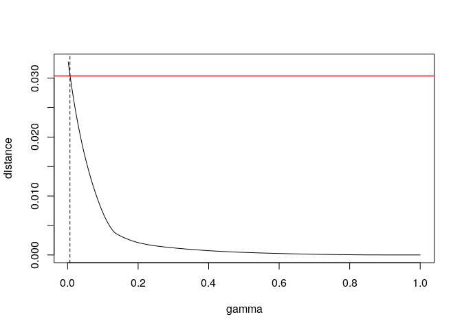

```r
plot(est.lwr.bnd)
```

### Estimation of (\alpha_0)

#### Pre-specified choice of (c_n)

The following code computes an estimate of (\alpha_0) using the default choice of the tuning parameter, i.e., (c_n = 0.1 \log(\log(n)))

```r
est.default <- mix.model(data.1, method = "fixed", gridsize = 600)
print(est.default)
```

```
## Call:mix.model(data = data.1, method = "fixed", gridsize = 600)
## [1] "Estimate of alp is 0.0916666666666667"
## [1] " The chosen value c_n is 0.182690266560073"
```

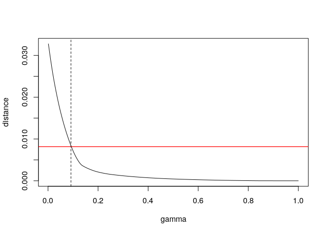

```r
plot(est.default)
```

The follwoing code gives an estimator of (\alpha_0) when (c_n) is chosen to be (0.05 \log\log(n))

```r
est.fixed <- mix.model(data.1, method = "fixed", c.n = .05*log(log(length(data.1))), gridsize = 600)
print(est.fixed)
plot(est.fixed)
```

[output not shown]

#### Cross validated choice of (c_n)

We can use the same function as above to compute the estimate of (\alpha_0) when (c_n) is chosen via cross-validation. The only difference being we have set *method* to be *cv*.

```r
est.cv <- mix.model(data.1, method = "cv", gridsize = 600)
print(est.cv)
```

```
## Call:mix.model(data = data.1, method = "cv", gridsize = 600)
## [1] "Estimate of alp is 0.128333333333333"
## [1] " The chosen value c_n is 0.089961116109127"
```

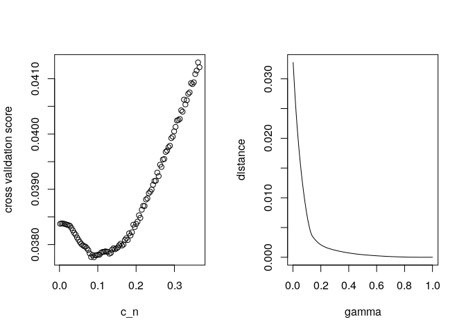

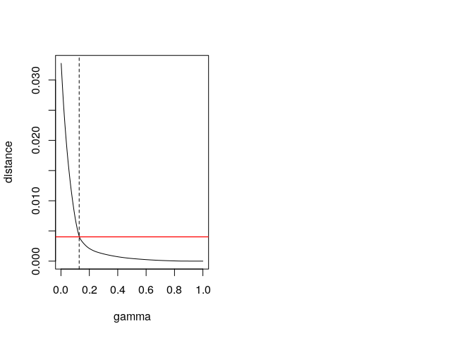

```r
plot(est.cv)
```

## References

Patra, Rohit Kumar, and Bodhisattva Sen. 2016. “Estimation of a Two-Component Mixture Model with Applications to Multiple Testing.” *J. R. Stat. Soc. Ser. B. Stat. Methodol.* 78 (4): 869–93. https://doi.org/10.1111/rssb.12148.